# Yolo Object Detection-106

```python
import cv2
import numpy as np
import matplotlib.pyplot as plt
import os
```

Git hub link, from the YOLO official website:https://pjreddie.com/darknet/yolo/

- https://github.com/pjreddie/darknet/blob/master/cfg/yolov3-tiny.cfg

```python
modelConf= "yolov3-tiny.cfg"
modelweights="yolov3-tiny.weights"
net= cv2.dnn.readNetFromDarknet(modelConf,modelweights)
net
```

```
< cv2.dnn.Net 000002304DFE9750>
```

```python
classessFile="coco.names"
with open(classessFile,'rt') as f:
    classes=f.read().rstrip('\n').split('\n')
classes
```

```
['person',
 'bicycle',
 'car',
 'motorbike',
 'aeroplane',
 'bus',
 'train',
 'truck',
 'boat',
 'traffic light',
 'fire hydrant',
 'stop sign',
 'parking meter',
 'bench',
 'bird',
 'cat',
 'dog',
 'horse',
 'sheep',
 'cow',
 'elephant',
 'bear',
 'zebra',
 'giraffe',
 'backpack',
 'umbrella',
 'handbag',
 'tie',
 'suitcase',
 'frisbee',
 'skis',
 'snowboard',
 'sports ball',
 'kite',
 'baseball bat',
 'baseball glove',
 'skateboard',
 'surfboard',
 'tennis racket',
 'bottle',
```

[output cut: 25 more lines]

```
 'remote',
 'keyboard',
 'cell phone',
 'microwave',
 'oven',
 'toaster',
 'sink',
 'refrigerator',
 'book',
 'clock',
 'vase',
 'scissors',
 'teddy bear',
 'hair drier',
 'toothbrush']
```

```python
len(classes)
```

```
80
```

```python
dir(net)
```

```
['__class__',
 '__delattr__',
 '__dir__',
 '__doc__',
 '__eq__',
 '__format__',
 '__ge__',
 '__getattribute__',
 '__getstate__',
 '__gt__',
 '__hash__',
 '__init__',
 '__init_subclass__',
 '__le__',
 '__lt__',
 '__module__',
 '__ne__',
 '__new__',
 '__reduce__',
 '__reduce_ex__',
 '__repr__',
 '__setattr__',
 '__sizeof__',
 '__str__',
 '__subclasshook__',
 'addLayer',
 'addLayerToPrev',
 'connect',
 'dump',
 'dumpToFile',
 'dumpToPbtxt',
 'empty',
 'enableFusion',
 'enableWinograd',
 'forward',
 'forwardAndRetrieve',
 'forwardAsync',
 'getFLOPS',
 'getInputDetails',
 'getLayer',
 'getLayerId',
 'getLayerNames',
 'getLayerTypes',
 'getLayersCount',
 'getLayersShapes',
 'getMemoryConsumption',
 'getOutputDetails',
 'getParam',
 'getPerfProfile',
 'getUnconnectedOutLayers',
 'getUnconnectedOutLayersNames',
 'quantize',
 'readFromModelOptimizer',
 'registerOutput',
 'setHalideScheduler',
 'setInput',
 'setInputShape',
 'setInputsNames',
 'setParam',
 'setPreferableBackend',
 'setPreferableTarget']
```

```python
l=net.getLayerNames() #number of layers
l
```

```
('conv_0',
 'bn_0',
 'leaky_1',
 'pool_1',
 'conv_2',
 'bn_2',
 'leaky_3',
 'pool_3',
 'conv_4',
 'bn_4',
 'leaky_5',
 'pool_5',
 'conv_6',
 'bn_6',
 'leaky_7',
 'pool_7',
 'conv_8',
 'bn_8',
 'leaky_9',
 'pool_9',
 'conv_10',
 'bn_10',
 'leaky_11',
 'pool_11',
 'conv_12',
 'bn_12',
 'leaky_13',
 'conv_13',
 'bn_13',
 'leaky_14',
 'conv_14',
 'bn_14',
 'leaky_15',
 'conv_15',
 'permute_16',
 'yolo_16',
 'identity_17',
 'conv_18',
 'bn_18',
 'leaky_19',
 'upsample_19',
 'concat_20',
 'conv_21',
 'bn_21',
 'leaky_22',
 'conv_22',
 'permute_23',
 'yolo_23')
```

```python
len(l)
```

```
48
```

```python
l1=net.getUnconnectedOutLayers()#yolo layers index
l1
```

```
array([36, 48], dtype=int32)
```

```python
l[35], l[47]
```

```
('yolo_16', 'yolo_23')
```

```python
l2=net.getUnconnectedOutLayersNames()
l2
```

```
('yolo_16', 'yolo_23')
```

# blobFromImage() function

It returns a 4-dimensional array/blob for the input image. You can additionally use it to preprocess your image by scaling, resizing, or normalizing. You can adjust its different parameters to transform your image,

so let’s discuss all its parameters:

**image**

This is the image that we want to preprocess (for our model)

**scalefactor**

scale factor basically multiplies (scales) our image channels. And remember that it scales it down by applying 1/scalefactor if a fraction is provided.

**size**

this is the target size that we want our image to become. Most common CNNs use 224×224 or 229×229. You should resize it to meet your model requirements.

**mean**

this is the mean subtracting values. You can input a single value or a 3-item tuple for each channel R, G, B. By subtracting from the channels accordingly, this is done to normalize our pixel values.

Note: mean argument utilizes the same units as pixel values.

**swapRB**

OpenCV by default reads an image in BGR format, but as mentioned above that the mean argument uses RGB order. To avoid any disruption, this function, as the name implies, swaps the red and blue channels. (i.e., why its default value is True).

```python
frame = cv2.imread('dog.jpg')
frame.shape
```

```
(386, 515, 3)
```

```python
# reshape the image
inpWidth = 416
inpHeight = 416

frame = cv2.imread('dog.jpg')

# generally image will take as BGR we need to change RGB
blob = cv2.dnn.blobFromImage(frame,
                             1/255,
                             (inpWidth, inpHeight),
                             [0,0,0],
                             1,
                             crop=False)   # pass the image
```

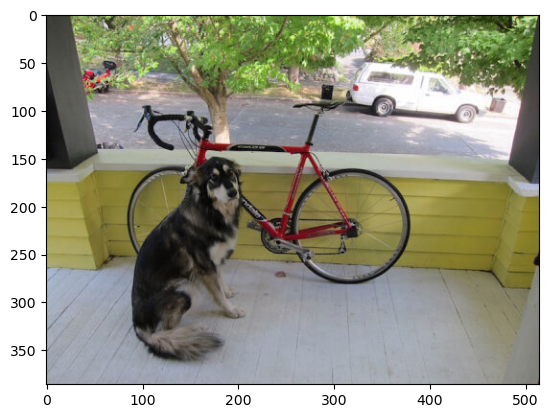

```python
# Change BGR to RGB
img=cv2.cvtColor(frame,cv2.COLOR_BGR2RGB)
plt.imshow(img)
```

```python
frame.shape
```

```
(386, 515, 3)
```

```python
blob.shape# blob will take in revrse
```

```
(1, 3, 416, 416)
```

```python
blob[0].shape
```

```
(3, 416, 416)
```

```python
net.setInput(blob)
# for the yolo arch, we cant pass direct image, we are converting image into blob
```

```python
yolo_layers=net.getUnconnectedOutLayersNames()
outs= net.forward(yolo_layers)
outs

# there are two yolo layers, and in image there are two objects, we have toatal 80 calses.
# we got 85 values, 5+ 80
# 5 are (x,y,w,h)-> bounding boxes, condidance
# 80 mean probabilities of each class
```

```
(array([[0.04674619, 0.0509331 , 0.209556  , ..., 0.        , 0.        ,
         0.        ],
        [0.03688651, 0.0525094 , 0.15892226, ..., 0.        , 0.        ,
         0.        ],
        [0.03384232, 0.04626564, 0.7868979 , ..., 0.        , 0.        ,
         0.        ],
        ...,
        [0.95022804, 0.9646796 , 0.18465139, ..., 0.        , 0.        ,
         0.        ],
        [0.9569391 , 0.9520573 , 0.18207322, ..., 0.        , 0.        ,
         0.        ],
        [0.9685841 , 0.9522542 , 0.7753742 , ..., 0.        , 0.        ,
         0.        ]], dtype=float32),
 array([[0.02005123, 0.01666236, 0.03133425, ..., 0.        , 0.        ,
         0.        ],
        [0.02489108, 0.02395572, 0.04274501, ..., 0.        , 0.        ,
         0.        ],
        [0.01504077, 0.01975115, 0.12213404, ..., 0.        , 0.        ,
         0.        ],
        ...,
        [0.973965  , 0.9782004 , 0.02505352, ..., 0.        , 0.        ,
         0.        ],
        [0.9749387 , 0.9713274 , 0.03731928, ..., 0.        , 0.        ,
         0.        ],
        [0.98076826, 0.9801091 , 0.11759661, ..., 0.        , 0.        ,
         0.        ]], dtype=float32))
```

```python
len(outs) # Two objects
```

```
2
```

```python
len(outs[0]) # model is identifies total 507 boxes and predictins

#5+80
# first 5 values are the x,y,w,h and confidence for the first box
# remaining 80 are the classes
```

```
507
```

```python
len(outs[1]) #2028 bounding boxes
```

```
2028
```

```python
len(outs[0][0])
```

```
85
```

```python
list(outs[0][0])[:5]
```

```
[np.float32(0.046746194),
 np.float32(0.0509331),
 np.float32(0.209556),
 np.float32(0.16903403),
 np.float32(7.25441e-06)]
```

```python
list(outs[0][0])[5:]# useless box, not identifing
```

```
[np.float32(0.0),
 np.float32(0.0),
 np.float32(0.0),
 np.float32(0.0),
 np.float32(0.0),
 np.float32(0.0),
 np.float32(0.0),
 np.float32(0.0),
 np.float32(0.0),
 np.float32(0.0),
 np.float32(0.0),
 np.float32(0.0),
 np.float32(0.0),
 np.float32(0.0),
 np.float32(0.0),
 np.float32(0.0),
 np.float32(0.0),
 np.float32(0.0),
 np.float32(0.0),
 np.float32(0.0),
 np.float32(0.0),
 np.float32(0.0),
 np.float32(0.0),
 np.float32(0.0),
 np.float32(0.0),
 np.float32(0.0),
 np.float32(0.0),
 np.float32(0.0),
 np.float32(0.0),
 np.float32(0.0),
 np.float32(0.0),
 np.float32(0.0),
 np.float32(0.0),
 np.float32(0.0),
 np.float32(0.0),
 np.float32(0.0),
 np.float32(0.0),
 np.float32(0.0),
 np.float32(0.0),
 np.float32(0.0),
```

[output cut: 25 more lines]

```
 np.float32(0.0),
 np.float32(0.0),
 np.float32(0.0),
 np.float32(0.0),
 np.float32(0.0),
 np.float32(0.0),
 np.float32(0.0),
 np.float32(0.0),
 np.float32(0.0),
 np.float32(0.0),
 np.float32(0.0),
 np.float32(0.0),
 np.float32(0.0),
 np.float32(0.0),
 np.float32(0.0)]
```

```python
outs[0][5]
```

```
array([1.1684998e-01, 5.0131679e-02, 6.5502423e-01, 6.8971050e-01,
       2.4278006e-07, 0.0000000e+00, 0.0000000e+00, 0.0000000e+00,
       0.0000000e+00, 0.0000000e+00, 0.0000000e+00, 0.0000000e+00,
       0.0000000e+00, 0.0000000e+00, 0.0000000e+00, 0.0000000e+00,
       0.0000000e+00, 0.0000000e+00, 0.0000000e+00, 0.0000000e+00,
       0.0000000e+00, 0.0000000e+00, 0.0000000e+00, 0.0000000e+00,
       0.0000000e+00, 0.0000000e+00, 0.0000000e+00, 0.0000000e+00,
       0.0000000e+00, 0.0000000e+00, 0.0000000e+00, 0.0000000e+00,
       0.0000000e+00, 0.0000000e+00, 0.0000000e+00, 0.0000000e+00,
       0.0000000e+00, 0.0000000e+00, 0.0000000e+00, 0.0000000e+00,
       0.0000000e+00, 0.0000000e+00, 0.0000000e+00, 0.0000000e+00,
       0.0000000e+00, 0.0000000e+00, 0.0000000e+00, 0.0000000e+00,
       0.0000000e+00, 0.0000000e+00, 0.0000000e+00, 0.0000000e+00,
       0.0000000e+00, 0.0000000e+00, 0.0000000e+00, 0.0000000e+00,
       0.0000000e+00, 0.0000000e+00, 0.0000000e+00, 0.0000000e+00,
       0.0000000e+00, 0.0000000e+00, 0.0000000e+00, 0.0000000e+00,
       0.0000000e+00, 0.0000000e+00, 0.0000000e+00, 0.0000000e+00,
       0.0000000e+00, 0.0000000e+00, 0.0000000e+00, 0.0000000e+00,
       0.0000000e+00, 0.0000000e+00, 0.0000000e+00, 0.0000000e+00,
       0.0000000e+00, 0.0000000e+00, 0.0000000e+00, 0.0000000e+00,
       0.0000000e+00, 0.0000000e+00, 0.0000000e+00, 0.0000000e+00,
       0.0000000e+00], dtype=float32)
```

```python
frameHeight = frame.shape[0]
frameWidth = frame.shape[1]

boxes = []
confidences = []
classIDs = []

for out in outs:  # calling each object boxes
    for detection in out:  # calling each box
        score = detection[5:]  # probability of 80 classes
        class_id = np.argmax(score)  # max probability id
        confidence = score[class_id]  # getting the confidence

        if confidence > 0.6:  # if confidence >70% consider as that object
            print(detection)

            centerX = int(detection[0] * frameWidth)   # before we pass the object we divide with frame width
            # these are the normilized values so multiply again
            centerY = int(detection[1] * frameHeight)
            width   = int(detection[2] * frameWidth)
            height  = int(detection[3] * frameHeight)

            left = int(centerX - width / 2)
            top  = int(centerY - height / 2)

            classIDs.append(class_id)
            confidences.append(float(confidence))
            boxes.append([left, top, width, height])
boxes
```

```
[0.7505262  0.21793431 0.29089767 0.15677741 0.9568654  0.
 0.         0.66080046 0.         0.         0.         0.
 0.41814622 0.         0.         0.         0.         0.
 0.         0.         0.         0.         0.         0.
 0.         0.         0.         0.         0.         0.
 0.         0.         0.         0.         0.         0.
 0.         0.         0.         0.         0.         0.
 0.         0.         0.         0.         0.         0.
 0.         0.         0.         0.         0.         0.
 0.         0.         0.         0.         0.         0.
 0.         0.         0.         0.         0.         0.
 0.         0.         0.         0.         0.         0.
 0.         0.         0.         0.         0.         0.
 0.         0.         0.         0.         0.         0.
 0.        ]
[0.33022735 0.6393397  0.34544155 0.5081224  0.6292958  0.
 0.         0.         0.         0.         0.         0.
 0.         0.         0.         0.         0.         0.
 0.         0.         0.         0.624893   0.         0.
 0.         0.         0.         0.         0.         0.
 0.         0.         0.         0.         0.         0.
 0.         0.         0.         0.         0.         0.
 0.         0.         0.         0.         0.         0.
 0.         0.         0.         0.         0.         0.
 0.         0.         0.         0.         0.         0.
 0.         0.         0.         0.         0.         0.
 0.         0.         0.         0.         0.         0.
 0.         0.         0.         0.         0.         0.
 0.         0.         0.         0.         0.         0.
 0.        ]
```

```
[[311, 54, 149, 60], [81, 148, 177, 196]]
```

```python
len(outs[0]), len(outs[1])
```

```
(507, 2028)
```

```python
507 + 2028
```

```
2535
```

```python
confidences
```

```
[0.6608004570007324, 0.6248930096626282]
```

# NMS: Non Max Suppresion

if we decrese the confidence percentage, then many boxes will come, the NMS will helps

by usinh IOU technique : Intersection of union

```python
indexes = cv2.dnn.NMSBoxes(boxes, confidences, 0.5, 0.4)
indexes   # surpass many boxes
```

```
array([0, 1], dtype=int32)
```

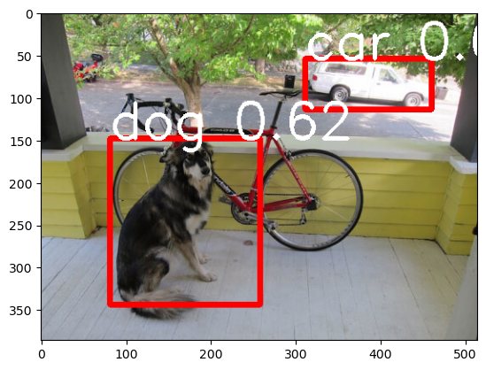

```python
font = cv2.FONT_HERSHEY_SIMPLEX
color = (255, 0, 0)  # RGB

for i in indexes:
    x, y, w, h = boxes[i]
    label = str(classes[classIDs[i]])
    confi = str(round(confidences[i], 2))
    # color = colors[i]

    cv2.rectangle(img, (x, y), (x + w, y + h), color, 5)   # (x,y): left,top
    cv2.putText(img, label + " " + confi, (x, y), font, 2, (255, 255, 255), 3)

plt.imshow(img)
```

# Method 1:

**Bounding Box on images**

```python
import cv2
import numpy as np
import matplotlib.pyplot as plt
import os
```

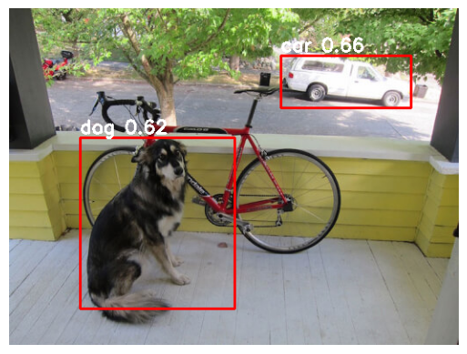

```python
# modelConf= "C:\\Users\\lib-illabc\\Desktop\\mmoham34\\Dataset\\YOLO\\yolov3-tiny.cfg"
# modelweights="C:\\Users\\lib-illabc\\Desktop\\mmoham34\\Dataset\\YOLO\\yolov3-tiny.weights"
# frame = cv2.imread('C:\\Users\\lib-illabc\\Desktop\\mmoham34\\Dataset\\DL\\dog.jpg')
# ---- paths / inputs ----
modelConf= "yolov3-tiny.cfg"
modelweights ="yolov3-tiny.weights"
classesFile = "coco.names"
image       = "dog.jpg"

# ---- post-process: parse detections, NMS, draw ----
def post_process(frame, outs, img, classes):
    frameHeight = frame.shape[0]
    frameWidth  = frame.shape[1]

    boxes = []
    confidences = []
    classIDs = []

    for out in outs:                         # calling each object boxes
        for detection in out:                # calling each box
            score = detection[5:]            # probabilities for 80 classes
            class_id = np.argmax(score)      # max probability id
            confidence = score[class_id]     # confidence of that class

            if confidence > 0.6:             # keep if conf > 70%
                # YOLO gives normalized cx,cy,w,h  → convert to pixels
                centerX = int(detection[0] * frameWidth)
                centerY = int(detection[1] * frameHeight)
                width   = int(detection[2] * frameWidth)
                height  = int(detection[3] * frameHeight)
                left    = int(centerX - width / 2)
                top     = int(centerY - height / 2)

                classIDs.append(class_id)
                confidences.append(float(confidence))
                boxes.append([left, top, width, height])

    # Non-Max Suppression to remove overlaps
    indexes = cv2.dnn.NMSBoxes(boxes, confidences, 0.5, 0.4)

    font  = cv2.FONT_HERSHEY_SIMPLEX
    color = (255, 0, 0)  # BGR for cv2 drawing

    if len(indexes) > 0:
        for i in np.array(indexes).flatten():
            x, y, w, h = boxes[i]
            label = str(classes[classIDs[i]])
            confi = str(round(confidences[i], 2))
            cv2.rectangle(img, (x, y), (x + w, y + h), color, 2)   # (x,y) = left, top
            cv2.putText(img, f"{label} {confi}", (x, y - 5), font, 0.7, (255, 255, 255), 2)

    # show result (img is RGB already)
    plt.imshow(img)
    plt.axis("off")
    plt.show()

# ---- all at one place ----
def yolo_out(modelConf, modelWeights, classesFile, image):
    net = cv2.dnn.readNetFromDarknet(modelConf, modelWeights)
    with open(classesFile, 'rt') as f:
        classes = f.read().rstrip('\n').split('\n')

    inpWidth  = 416
    inpHeight = 416

    frame = cv2.imread(image)
    img   = cv2.cvtColor(frame, cv2.COLOR_BGR2RGB)  # for matplotlib display

    # create blob (as in your screenshot)
    blob = cv2.dnn.blobFromImage(frame, 1/255, (inpWidth, inpHeight), [0,0,0], 1, crop=False)
    net.setInput(blob)

    yolo_layers = net.getUnconnectedOutLayersNames()
    outs = net.forward(yolo_layers)

    post_process(frame, outs, img, classes)

# ---- run ----
yolo_out(modelConf, modelweights, classesFile, image)
```

```python
# Streamlit application
# yolov8
# object tracking
# vehicle counter
# pose detection
# RCNN
```